# rfPermute: Estimation of predictor importance significance in Random Forest models

Frederick I. Archer

### Introduction

Since its inception, the ensemble machine learning algorithm, Random Forest (Breiman 2001), has been rapidly gaining popularity as a powerful tool for classification and uncovering patterns in complex data sets. It has been used a wide variety of fields (Cutler et al. 2007, Winham et al. 2012, Touw et al. 2012), and has proven to be robust in performance tests against other commonly used modelling algorithms (Berk 2006).

The most commonly used implementation of Random Forest is the *randomForest* package in R (Liaw and Weiner 2002). This package allows easy specification of both classification and regression models and provides several useful functions for summarizing their results. One of the metrics that many users of Random Forest are interested in examining are the measures of variable or predictor importance. The importance of a predictor is estimated by measuring the decrease in prediction accuracy when that predictor is permuted in each tree in the forest. These values are often used to identify and rank those predictors that are most related to the response and critical for classification. More detail about how the various importance metrics are computed can be found in Liaw and Weiner (2002) and Breiman (2002).

However, *randomForest* only produces raw measures of predictor importance and it is up to the user to identify cutoff values above which predictors would be considered to have a significant impact on model predictions. In order to address this, I have implemented a permutation test in *rfPermute* which generates a null distribution of importance scores for each predictor against which the observed importance scores are compared. This null distribution is created by randomly permuting the response variable (class assignments in a classification model, or independent continuous response in a regression model) among cases, running the same Random Forest model on the permuted data, and storing the resulting importance scores.

Under this procedure, a predictor that is not adding any significant information to the model will have an observed importance score that is similar to those generated by a random shuffling of the response, while a significant predictor will have an importance score much larger than the null. Significance p-values are then calculated as the fraction of replicates in the null distribution that are greater than or equal to the observed value. *rfPermute* provides both the p-values and the null distribution which the user can use for variable selection and further exploration.

### Execution

*rfPermute* provides a wrapper for the *randomForest* function that accepts all of its arguments, plus two additional ones: *nrep*, which is an integer specifying the number of permutation replicates to run, and *num.cores*, which is an integer specifying the number of CPU cores to distribute the permutations over on a multi-core system. If *nrep* is set to 0, then the return value is a list with the same elements as the equivalent call to *randomForest*. With one or more permutation replicates specified, the returned list contains two elements: *null.dist*, which is a list containing arrays of the null distributions for unscaled and scaled importance measures, and *pval*, which is an array containing the permutation p-values for unscaled and scaled importance measures.

As an example, we use a data set of metabolite profiles measured to create a classifier for four clades of the endosymbiont dinoflagellate *Symbiodinium* as published in Klueter et al (2015). Significance is measured with 1000 permutations. Because each *Symbiodinium* type is represented by 16 cases in this data set, we create a model where 8 cases from each type are used in each tree and sampling is done without replacement. *rfPermute* automatically sets `importance = TRUE` to force `randomForest` to calculate and return the matrix of importance scores, so we don’t need to set that. However, we will be using the proximity matrix later, so we must specify `proximity = TRUE`.

```r
# Load the library
library(rfPermute)
```

```r
# Load the included data
data(symb.metab)

# Create the randomForest model with 1000 permutations.
metab.rf <- rfPermute(type ~ ., data = symb.metab, sampsize = rep(8, 4), replace = FALSE, proximity = TRUE, nrep = 1000)
metab.rf
```

```
##
## Call:
##  randomForest(formula = type ~ ., data = symb.metab, sampsize = rep(8,      4), replace = FALSE, proximity = TRUE)
##                Type of random forest: classification
##                      Number of trees: 500
## No. of variables tried at each split: 12
##
##         OOB estimate of  error rate: 7.81%
## Confusion matrix:
##      A194 B184 B224 D206 class.error
## A194   14    1    1    0      0.1250
## B184    0   16    0    0      0.0000
## B224    0    1   14    1      0.1250
## D206    0    1    0   15      0.0625
```

The result is a ‘rfPermute’ object that inherits from and has the same components as a ‘randomForest’ object, plus ‘null.dist’ and ‘pval’:

```r
class(metab.rf)
```

```
## [1] "rfPermute"            "randomForest.formula" "randomForest"
```

```r
names(metab.rf)
```

```
##  [1] "call"            "type"            "predicted"
##  [4] "err.rate"        "confusion"       "votes"
##  [7] "oob.times"       "classes"         "importance"
## [10] "importanceSD"    "localImportance" "proximity"
## [13] "ntree"           "mtry"            "forest"
## [16] "y"               "test"            "inbag"
## [19] "null.dist"       "pval"            "terms"
```

```r
str(metab.rf$null.dist)
```

```
## List of 2
##  $ unscaled: num [1:155, 1:6, 1:1000] -0.00175 0.0005 -0.0015 -0.00075 -0.001 -0.00075 -0.00125 -0.002 -0.001 -0.00225 ...
##   ..- attr(*, "dimnames")=List of 3
##   .. ..$ : chr [1:155] "Amino.Acid.2" "Amino.Acid.3" "Alanine" "Amino.Acid.4" ...
##   .. ..$ : chr [1:6] "A194" "B184" "B224" "D206" ...
##   .. ..$ : NULL
##  $ scaled  : num [1:155, 1:6, 1:1000] -2.12 0.707 -1.503 -1.001 -1.267 ...
##   ..- attr(*, "dimnames")=List of 3
##   .. ..$ : chr [1:155] "Amino.Acid.2" "Amino.Acid.3" "Alanine" "Amino.Acid.4" ...
##   .. ..$ : chr [1:6] "A194" "B184" "B224" "D206" ...
##   .. ..$ : NULL
```

```r
str(metab.rf$pval)
```

```
##  num [1:155, 1:6, 1:2] 0.396 0.313 0.533 0.251 0.707 ...
##  - attr(*, "dimnames")=List of 3
##   ..$ : chr [1:155] "Amino.Acid.2" "Amino.Acid.3" "Alanine" "Amino.Acid.4" ...
##   ..$ : chr [1:6] "A194" "B184" "B224" "D206" ...
##   ..$ : chr [1:2] "unscaled" "scaled"
```

### Predictor significance

The permutation p-values for predictors in the `rfPermute` object can be accessed using the `rp.importance` function, which behaves in the same manner as `randomForest::importance`, returning a matrix of the scaled or unscaled importance scores along with their respective p-values:

```r
imp <- rp.importance(metab.rf)
head(imp)
```

```
##                      A194   A194.pval      B184   B184.pval     B224
## C30..5.Sterol    8.150310 0.000999001 10.056936 0.000999001 7.605071
## C29.Stanol.2     6.751367 0.000999001  6.846638 0.000999001 5.334064
## C28..5.Sterol    8.632484 0.000999001  6.088108 0.000999001 5.319236
## Sugar.17         5.914432 0.001998002  5.401022 0.000999001 7.881701
## C28..5.22.Sterol 4.070348 0.001998002  6.861894 0.000999001 4.593396
## Closed.Hexose.5  7.936629 0.000999001  6.679558 0.000999001 2.795085
##                    B224.pval       D206   D206.pval MeanDecreaseAccuracy
## C30..5.Sterol    0.000999001 10.9235010 0.000999001            11.336668
## C29.Stanol.2     0.000999001  8.7795390 0.000999001             9.466574
## C28..5.Sterol    0.000999001  4.3592078 0.001998002             8.911195
## Sugar.17         0.000999001  6.8680282 0.000999001             8.618094
## C28..5.22.Sterol 0.000999001  7.5544549 0.000999001             8.602659
## Closed.Hexose.5  0.012987013  0.7849477 0.235764236             8.045476
##                  MeanDecreaseAccuracy.pval MeanDecreaseGini
## C30..5.Sterol                  0.000999001        1.6089035
## C29.Stanol.2                   0.000999001        1.1186261
## C28..5.Sterol                  0.000999001        1.0127599
## Sugar.17                       0.000999001        1.0927187
## C28..5.22.Sterol               0.000999001        0.8674602
## Closed.Hexose.5                0.000999001        0.7865478
##                  MeanDecreaseGini.pval
## C30..5.Sterol              0.000999001
## C29.Stanol.2               0.000999001
## C28..5.Sterol              0.000999001
## Sugar.17                   0.000999001
## C28..5.22.Sterol           0.000999001
## Closed.Hexose.5            0.000999001
```

A density plot of the null distribution of predictor importances along with the observed importance value can be visulized with the `plotNull` function. Here we see the null distribution Mean Decrease in Accuracy of one metabolite (Disaccharide.8), which has a p-value of 0.014.

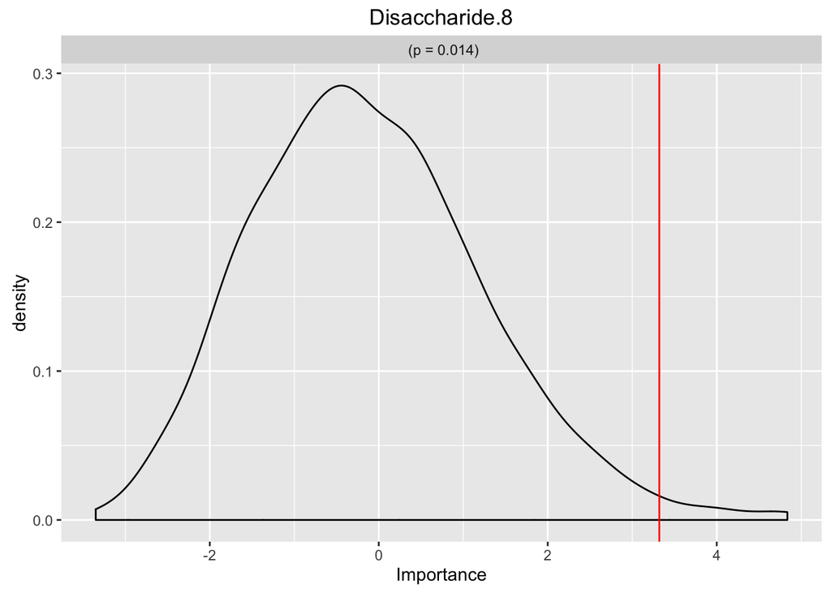

```r
plotNull(metab.rf, preds = "Disaccharide.8", imp.type = "MeanDecreaseAccuracy")
```

An ordered bar chart of all predictor importances with designations of their significance at a specified critical alpha (traditionally 0.05), can be visualized with the `plot` function applied to the result of `rp.importance`, like so:

[figure not shown]

```r
# Here are all of the predictors. Those colored red have p-values <= 0.05
plot(imp)
```

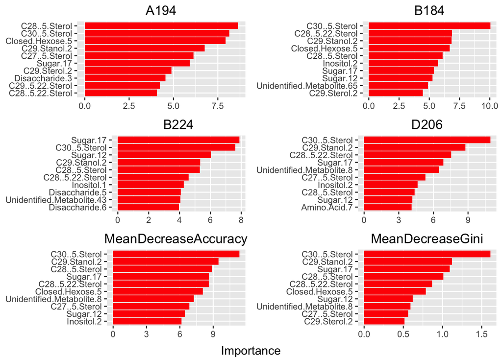

```r
# Here we just show the top 10 most important predictors for each importance type
plot(imp, n = 10)
```

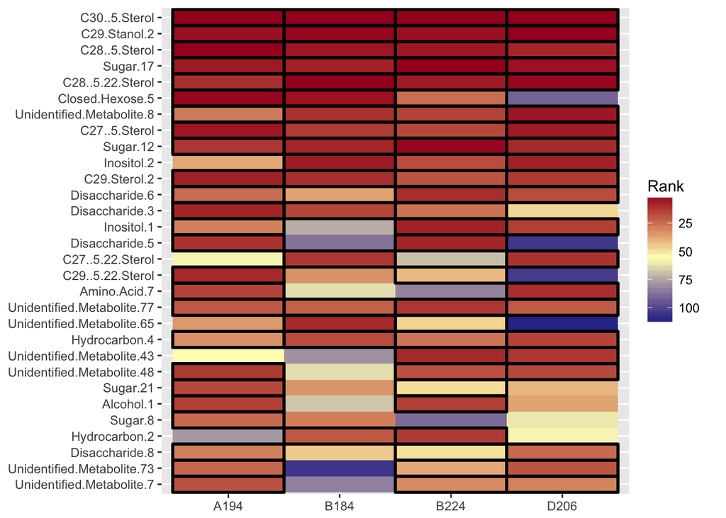

```r
impHeatmap(metab.rf, n = 30)
```

### Model summary functions

`rfPermute` also provides a set of convenient summary functions for *randomForest* models. For classification models, in order to evaluate how well the model is performing, one should compare the observed OOB error rates to what would be expected if samples were just randomly allocated to bins in the absence of information from predictor variables. This rate turns out to simply be the fraction of the total sample size represented by each class. In a simple two-class model, with equal sample sizes in each class, this is then 50% for both classes. However, if the sample sizes are skewed, say 80 in class A, and 10 in class B, then one would expect on average to correctly classify 80 / 90 of the class A samples and 10 / 90 of the class B samples. Thus the expected error rates would be 0.11 for class A and 0.89 for class B. These values, referred to as “priors” are calculated by the `exptdErrRate` function:

```r
# Since this data set has equal sample sizes, these will all be the same
exptdErrRate(metab.rf)
```

```
##  OOB A194 B184 B224 D206
## 0.75 0.75 0.75 0.75 0.75
```

The `classConfInt` function provides confidence intervals for the class-specific and overall model classification scores based on a binomial distribution. This helps provide a measure of uncertainty of the true classification rate given the observed sample sizes:

```r
classConfInt(metab.rf)
```

```
##         pct.correct  LCI_0.95  UCI_0.95 Pr.gt_0.8
## A194       0.875000 0.6165238 0.9844864 0.8592625
## B184       1.000000 0.7940928 1.0000000 1.0000000
## B224       0.875000 0.6165238 0.9844864 0.8592625
## D206       0.937500 0.6976793 0.9984189 0.9718525
## Overall    0.921875 0.8270217 0.9741462 0.9979437
```

A complete summary of the *randomForest* classification model can be produced by combinging the results of `classConfInt` and `exptdErrRate` along with the full confusion matrix as in the function, `confusionMatrix`:

```r
confusionMatrix(metab.rf)
```

```
##         A194 B184 B224 D206 pct.correct LCI_0.95  UCI_0.95 Pr.gt_0.8 Prior
## A194      14    1    1    0     87.5000 61.65238  98.44864  85.92625    25
## B184       0   16    0    0    100.0000 79.40928 100.00000 100.00000    25
## B224       0    1   14    1     87.5000 61.65238  98.44864  85.92625    25
## D206       0    1    0   15     93.7500 69.76793  99.84189  97.18525    25
## Overall   NA   NA   NA   NA     92.1875 82.70217  97.41462  99.79437    25
```

Note that in this matrix, the `pct.correct` column is 100 * (1 - OOB error rate) as I have found that this scale is more easily comprehended by people unfamiliar with Random Forest or classification algorithms.

### Vote distributions

When evaluating a Random Forest model, it can be useful to visualize the distribution of votes for classes within the forest. From these distributions, we can tell if individual cases are tending to be correctly classified with large probabilities (have a high fraction of trees voting for the correct class), or have equivocal assignments (vote probabilities are roughly equal). We can also see if misclassified samples were strongly or weakly misclassified. The `plotVotes` function will produce such a distribution, either as a bar chart, which is useful when few samples are present, or as an area chart, which is more readable with many samples:

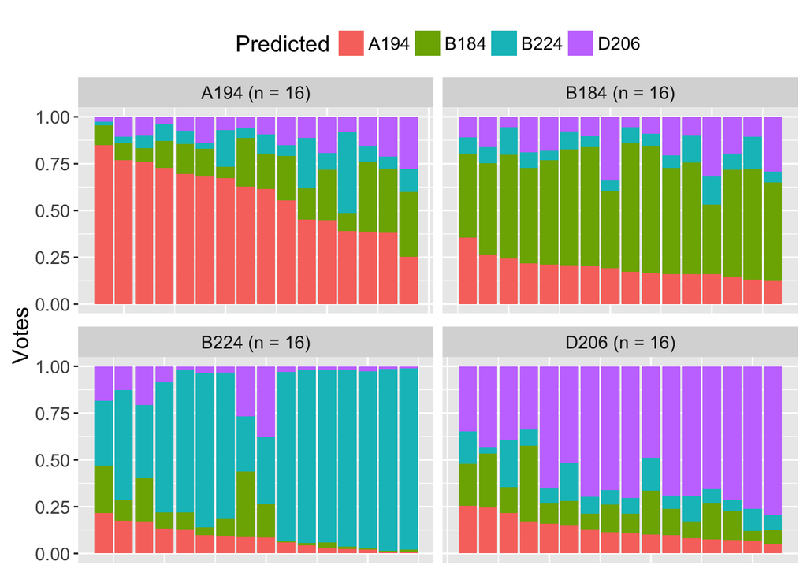

```r
plotVotes(metab.rf)
```

### Proximity plots

For visualizing the relative distribution of samples in the Random Forest, multi-dimensional scaling (MDS) is applied to the proxmity matrix computed by `randomForest`. The *randomForest* package provides the `MDSplot` function which uses base graphics to visualize these points. In *rfPermute* there is the `proximityPlot` function which uses *ggplot* graphics and provides a few additional useful features. The result of `proximityPlot` depicts the MDS project of cases, with classes encircled by a shaded convex hull. Additionally, each case is represented by a color-coded dot and circle. The color of the interior dot corresponds to the original case, while the color of the exterior circle corresponds to the predicted case. Thus, correctly classified cases will have the same color, while misclassified cases will have different colors, as in this example:

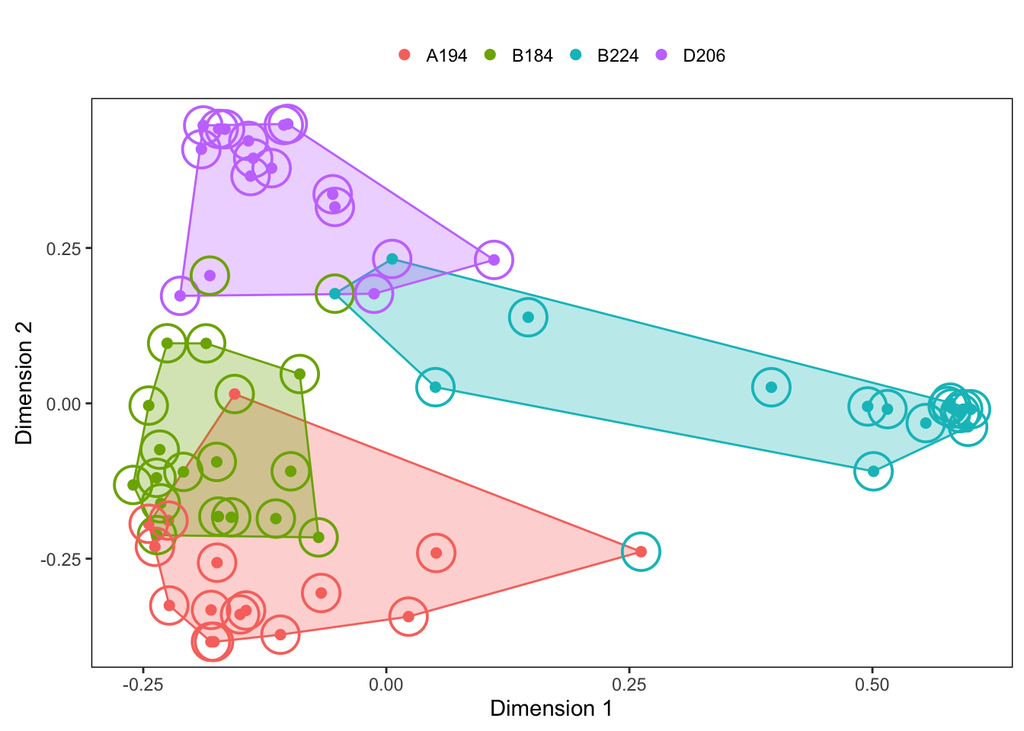

```r
proximityPlot(metab.rf)
```

### Performance

Because the primary function, `rfPermute`, is a wrapper that calls `randomForest` multiple times, execution time can be lengthy for large data sets and will scale relatively linearly with the number of permutations. However, execution time can be reduced if a multi-core machine is used and the `num.cores` argument set appropriately. For example, on a MacBook Pro with a 2.8GHz Intel Core i7 chip and 16GB of 1600 MHz DDR3 RAM, one `randomForest` run of the *Symbiodinium* data set took approximately 0.1 seconds. The same `rfPermute` model with 100 replicates took 14.4 seconds, and 1000 replicates took 142.3 seconds. When the number of cores used was increased from one to three, the 1000 replicate model took 46 seconds.

### Installation

The stable version of *rfPermute* can be installed from CRAN via:

```r
install.packages('rfPermute')
```

To install the latest development version from GitHub, use:

```r
# make sure you have Rtools installed
if (!require('devtools')) install.packages('devtools')

# install from GitHub
devtools::install_github('EricArcher/rfPermute')
```

### References

Berk, R. 2006. An introduction to ensemble methods for data analysis. Sociological Methods and Research 34:263-295.

Breiman, L. 2001. Random forests. Machine Learning 45:5-32.

Breiman, L. 2002. Manual on setting up, using, and understanding random forests v3.1. http://oz.berkeley.edu/users/breiman/Using_random_forests_V3.1.pdf.

Cutler, D. R., T. C. J. Edwards, K. H. Beard, A. Cutler, K. T. Hess, J. Gibson and J. J. Lawler. 2007. Random forests for classification in ecology. Ecology 88:2783-2792.

Touw, W. G., J. R. Bayjanov, L. Overmars, L. Backus, J. Boekhorst, M. Wels and S. a. F. T. Van Hijum. 2013. Data mining in the life sciences with random forest: a walk in the park or lost in the jungle? Briefings in Bioinformatics 14(3):315-26.

Winham, S. J., C. L. Colby, R. R. Freimuth, X. Wang, M. De Andrade, M. Huebner and J. M. Biernacka. 2012. SNP interaction detection with Random Forests in high-dimensional genetic data. BMC Bioinformatics 13:164.